# Risk Factor Analysis

## Outcome Variable

**Outcome Variable:** wasted

## Predictor Variables

**Intervention Variable:** mhtcm

**Adjustment Set:**

- arm
- W_mage
- meducyrs
- feducyrs
- hhwealth_quart
- W_nrooms
- impfloor
- impsan
- safeh20
- delta_W_mage
- delta_meducyrs
- delta_feducyrs
- delta_hhwealth_quart
- delta_W_nrooms
- delta_impfloor
- delta_impsan
- delta_safeh20

## Stratifying Variables

The analysis was stratified on these variable(s):

- agecat
- studyid
- country

## Data Summary

| agecat | studyid | country | mhtcm | wasted | n_cell | n |
| --- | --- | --- | --- | --- | --- | --- |
| Birth | ki0047075b-MAL-ED | BANGLADESH | >=155 cm | 0 | 21 | 233 |
| Birth | ki0047075b-MAL-ED | BANGLADESH | >=155 cm | 1 | 3 | 233 |
| Birth | ki0047075b-MAL-ED | BANGLADESH | <151 cm | 0 | 121 | 233 |
| Birth | ki0047075b-MAL-ED | BANGLADESH | <151 cm | 1 | 24 | 233 |
| Birth | ki0047075b-MAL-ED | BANGLADESH | [151-155) cm | 0 | 52 | 233 |
| Birth | ki0047075b-MAL-ED | BANGLADESH | [151-155) cm | 1 | 12 | 233 |
| Birth | ki0047075b-MAL-ED | BRAZIL | >=155 cm | 0 | 101 | 176 |
| Birth | ki0047075b-MAL-ED | BRAZIL | >=155 cm | 1 | 4 | 176 |
| Birth | ki0047075b-MAL-ED | BRAZIL | <151 cm | 0 | 44 | 176 |
| Birth | ki0047075b-MAL-ED | BRAZIL | <151 cm | 1 | 2 | 176 |
| Birth | ki0047075b-MAL-ED | BRAZIL | [151-155) cm | 0 | 25 | 176 |
| Birth | ki0047075b-MAL-ED | BRAZIL | [151-155) cm | 1 | 0 | 176 |
| Birth | ki0047075b-MAL-ED | INDIA | >=155 cm | 0 | 38 | 195 |
| Birth | ki0047075b-MAL-ED | INDIA | >=155 cm | 1 | 7 | 195 |
| Birth | ki0047075b-MAL-ED | INDIA | <151 cm | 0 | 77 | 195 |
| Birth | ki0047075b-MAL-ED | INDIA | <151 cm | 1 | 17 | 195 |
| Birth | ki0047075b-MAL-ED | INDIA | [151-155) cm | 0 | 48 | 195 |
| Birth | ki0047075b-MAL-ED | INDIA | [151-155) cm | 1 | 8 | 195 |
| Birth | ki0047075b-MAL-ED | NEPAL | >=155 cm | 0 | 25 | 167 |
| Birth | ki0047075b-MAL-ED | NEPAL | >=155 cm | 1 | 2 | 167 |
| Birth | ki0047075b-MAL-ED | NEPAL | <151 cm | 0 | 81 | 167 |
| Birth | ki0047075b-MAL-ED | NEPAL | <151 cm | 1 | 12 | 167 |
| Birth | ki0047075b-MAL-ED | NEPAL | [151-155) cm | 0 | 41 | 167 |
| Birth | ki0047075b-MAL-ED | NEPAL | [151-155) cm | 1 | 6 | 167 |
| Birth | ki0047075b-MAL-ED | PERU | >=155 cm | 0 | 55 | 269 |
| Birth | ki0047075b-MAL-ED | PERU | >=155 cm | 1 | 1 | 269 |
| Birth | ki0047075b-MAL-ED | PERU | <151 cm | 0 | 152 | 269 |
| Birth | ki0047075b-MAL-ED | PERU | <151 cm | 1 | 4 | 269 |
| Birth | ki0047075b-MAL-ED | PERU | [151-155) cm | 0 | 56 | 269 |
| Birth | ki0047075b-MAL-ED | PERU | [151-155) cm | 1 | 1 | 269 |

[output cut: 318 more lines]

The following strata were considered:

- agecat: 24 months, studyid: ki0047075b-MAL-ED, country: BANGLADESH
- agecat: 24 months, studyid: ki0047075b-MAL-ED, country: BRAZIL
- agecat: 24 months, studyid: ki0047075b-MAL-ED, country: INDIA
- agecat: 24 months, studyid: ki0047075b-MAL-ED, country: NEPAL
- agecat: 24 months, studyid: ki0047075b-MAL-ED, country: PERU
- agecat: 24 months, studyid: ki0047075b-MAL-ED, country: SOUTH AFRICA
- agecat: 24 months, studyid: ki0047075b-MAL-ED, country: TANZANIA, UNITED REPUBLIC OF
- agecat: 24 months, studyid: ki1017093-NIH-Birth, country: BANGLADESH
- agecat: 24 months, studyid: ki1017093b-PROVIDE, country: BANGLADESH
- agecat: 24 months, studyid: ki1017093c-NIH-Crypto, country: BANGLADESH
- agecat: 24 months, studyid: ki1066203-TanzaniaChild2, country: TANZANIA, UNITED REPUBLIC OF
- agecat: 24 months, studyid: ki1101329-Keneba, country: GAMBIA
- agecat: 24 months, studyid: ki1119695-PROBIT, country: BELARUS
- agecat: 24 months, studyid: ki1126311-ZVITAMBO, country: ZIMBABWE
- agecat: 24 months, studyid: ki1135781-COHORTS, country: GUATEMALA
- agecat: 24 months, studyid: ki1135781-COHORTS, country: INDIA
- agecat: 24 months, studyid: ki1135781-COHORTS, country: PHILIPPINES
- agecat: 24 months, studyid: ki1148112-LCNI-5, country: MALAWI
- agecat: 24 months, studyid: kiGH5241-JiVitA-3, country: BANGLADESH
- agecat: 6 months, studyid: ki0047075b-MAL-ED, country: BANGLADESH
- agecat: 6 months, studyid: ki0047075b-MAL-ED, country: BRAZIL
- agecat: 6 months, studyid: ki0047075b-MAL-ED, country: INDIA
- agecat: 6 months, studyid: ki0047075b-MAL-ED, country: NEPAL
- agecat: 6 months, studyid: ki0047075b-MAL-ED, country: PERU
- agecat: 6 months, studyid: ki0047075b-MAL-ED, country: SOUTH AFRICA
- agecat: 6 months, studyid: ki0047075b-MAL-ED, country: TANZANIA, UNITED REPUBLIC OF
- agecat: 6 months, studyid: ki1000304b-SAS-CompFeed, country: INDIA
- agecat: 6 months, studyid: ki1000304b-SAS-FoodSuppl, country: INDIA
- agecat: 6 months, studyid: ki1017093-NIH-Birth, country: BANGLADESH
- agecat: 6 months, studyid: ki1017093b-PROVIDE, country: BANGLADESH
- agecat: 6 months, studyid: ki1017093c-NIH-Crypto, country: BANGLADESH
- agecat: 6 months, studyid: ki1066203-TanzaniaChild2, country: TANZANIA, UNITED REPUBLIC OF
- agecat: 6 months, studyid: ki1101329-Keneba, country: GAMBIA
- agecat: 6 months, studyid: ki1112895-Guatemala BSC, country: GUATEMALA
- agecat: 6 months, studyid: ki1119695-PROBIT, country: BELARUS
- agecat: 6 months, studyid: ki1126311-ZVITAMBO, country: ZIMBABWE
- agecat: 6 months, studyid: ki1135781-COHORTS, country: GUATEMALA
- agecat: 6 months, studyid: ki1135781-COHORTS, country: INDIA
- agecat: 6 months, studyid: ki1135781-COHORTS, country: PHILIPPINES
- agecat: 6 months, studyid: ki1148112-LCNI-5, country: MALAWI
- agecat: 6 months, studyid: kiGH5241-JiVitA-3, country: BANGLADESH
- agecat: Birth, studyid: ki0047075b-MAL-ED, country: BANGLADESH
- agecat: Birth, studyid: ki0047075b-MAL-ED, country: BRAZIL
- agecat: Birth, studyid: ki0047075b-MAL-ED, country: INDIA
- agecat: Birth, studyid: ki0047075b-MAL-ED, country: NEPAL
- agecat: Birth, studyid: ki0047075b-MAL-ED, country: PERU
- agecat: Birth, studyid: ki0047075b-MAL-ED, country: SOUTH AFRICA
- agecat: Birth, studyid: ki0047075b-MAL-ED, country: TANZANIA, UNITED REPUBLIC OF
- agecat: Birth, studyid: ki1000304b-SAS-CompFeed, country: INDIA
- agecat: Birth, studyid: ki1017093-NIH-Birth, country: BANGLADESH
- agecat: Birth, studyid: ki1017093c-NIH-Crypto, country: BANGLADESH
- agecat: Birth, studyid: ki1101329-Keneba, country: GAMBIA
- agecat: Birth, studyid: ki1119695-PROBIT, country: BELARUS
- agecat: Birth, studyid: ki1126311-ZVITAMBO, country: ZIMBABWE
- agecat: Birth, studyid: ki1135781-COHORTS, country: GUATEMALA
- agecat: Birth, studyid: ki1135781-COHORTS, country: INDIA
- agecat: Birth, studyid: ki1135781-COHORTS, country: PHILIPPINES
- agecat: Birth, studyid: kiGH5241-JiVitA-3, country: BANGLADESH

### Dropped Strata

Some strata were dropped due to rare outcomes:

- agecat: Birth, studyid: ki0047075b-MAL-ED, country: BANGLADESH
- agecat: Birth, studyid: ki0047075b-MAL-ED, country: BRAZIL
- agecat: Birth, studyid: ki0047075b-MAL-ED, country: NEPAL
- agecat: Birth, studyid: ki0047075b-MAL-ED, country: PERU
- agecat: Birth, studyid: ki0047075b-MAL-ED, country: SOUTH AFRICA
- agecat: Birth, studyid: ki0047075b-MAL-ED, country: TANZANIA, UNITED REPUBLIC OF
- agecat: Birth, studyid: ki1000304b-SAS-CompFeed, country: INDIA
- agecat: Birth, studyid: ki1017093-NIH-Birth, country: BANGLADESH
- agecat: Birth, studyid: ki1017093c-NIH-Crypto, country: BANGLADESH
- agecat: Birth, studyid: ki1101329-Keneba, country: GAMBIA
- agecat: 6 months, studyid: ki0047075b-MAL-ED, country: BANGLADESH
- agecat: 6 months, studyid: ki0047075b-MAL-ED, country: BRAZIL
- agecat: 6 months, studyid: ki0047075b-MAL-ED, country: INDIA
- agecat: 6 months, studyid: ki0047075b-MAL-ED, country: NEPAL
- agecat: 6 months, studyid: ki0047075b-MAL-ED, country: PERU
- agecat: 6 months, studyid: ki0047075b-MAL-ED, country: SOUTH AFRICA
- agecat: 6 months, studyid: ki0047075b-MAL-ED, country: TANZANIA, UNITED REPUBLIC OF
- agecat: 6 months, studyid: ki1017093c-NIH-Crypto, country: BANGLADESH
- agecat: 6 months, studyid: ki1112895-Guatemala BSC, country: GUATEMALA
- agecat: 6 months, studyid: ki1119695-PROBIT, country: BELARUS
- agecat: 6 months, studyid: ki1135781-COHORTS, country: GUATEMALA
- agecat: 6 months, studyid: ki1148112-LCNI-5, country: MALAWI
- agecat: 24 months, studyid: ki0047075b-MAL-ED, country: BANGLADESH
- agecat: 24 months, studyid: ki0047075b-MAL-ED, country: BRAZIL
- agecat: 24 months, studyid: ki0047075b-MAL-ED, country: INDIA
- agecat: 24 months, studyid: ki0047075b-MAL-ED, country: NEPAL
- agecat: 24 months, studyid: ki0047075b-MAL-ED, country: PERU
- agecat: 24 months, studyid: ki0047075b-MAL-ED, country: SOUTH AFRICA
- agecat: 24 months, studyid: ki0047075b-MAL-ED, country: TANZANIA, UNITED REPUBLIC OF
- agecat: 24 months, studyid: ki1066203-TanzaniaChild2, country: TANZANIA, UNITED REPUBLIC OF
- agecat: 24 months, studyid: ki1119695-PROBIT, country: BELARUS
- agecat: 24 months, studyid: ki1148112-LCNI-5, country: MALAWI

## Methods Detail

We’re interested in the causal parameters $E[Y_a]$ for all values of $a \in \mathcal{A}$. These parameters represent the mean outcome if, possibly contrary to fact, we intervened to set all units to have $A=a$. Under the randomization and positivity assumptions, these are identified by the statistical parameters $\psi_a=E_W[E_{Y|A,W}(Y|A=a,W)]$. In addition, we’re interested in the mean of $Y$, $E[Y]$ under no intervention (the observed mean). We will estimate these parameters by using SuperLearner to fit the relevant likelihood factors – $E_{Y|A,W}(Y|A=a,W)$ and $p(A=a|W)$, and then updating our likelihood fit using a joint TMLE.

For unadjusted analyses ($W=\{\}$), initial likelihoods were estimated using Lrnr_glm to estimate the simple $E(Y|A)$ and Lrnr_mean to estimate $p(A)$. For adjusted analyses, a small library containing Lrnr_glmnet, Lrnr_xgboost, and Lrnr_mean was used.

Having estimated these parameters, we will then use the delta method to estimate relative risks and attributable risks relative to a prespecified baseline level of $A$.

# Results Detail

## Results Plots

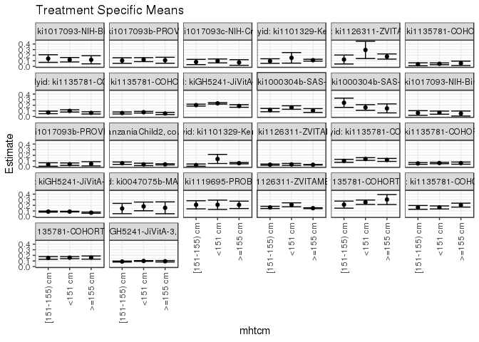

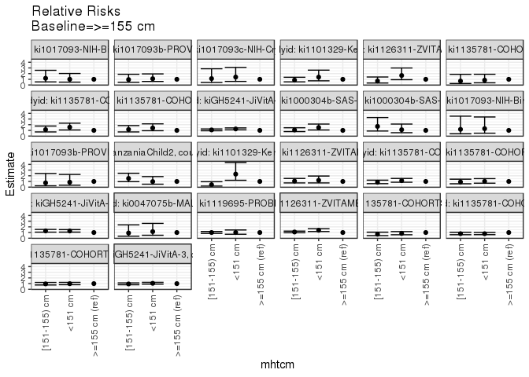

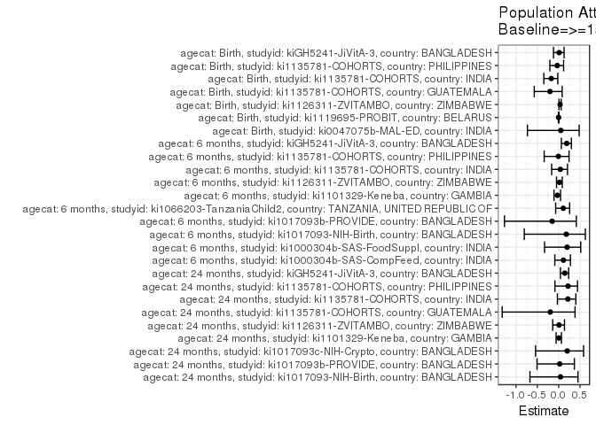

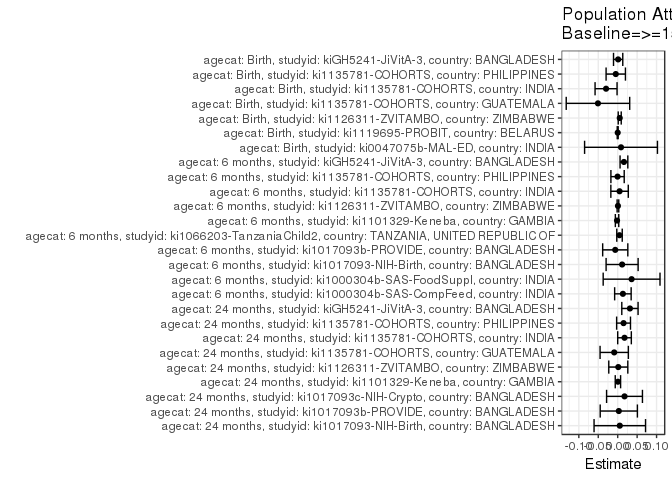

## Results Table

### Parameter: TSM

| agecat | studyid | country | intervention_level | baseline_level | estimate | ci_lower | ci_upper |
| --- | --- | --- | --- | --- | --- | --- | --- |
| Birth | ki0047075b-MAL-ED | INDIA | >=155 cm | NA | 0.1555556 | 0.0493893 | 0.2617218 |
| Birth | ki0047075b-MAL-ED | INDIA | <151 cm | NA | 0.1808511 | 0.1028424 | 0.2588597 |
| Birth | ki0047075b-MAL-ED | INDIA | [151-155) cm | NA | 0.1428571 | 0.0509714 | 0.2347429 |
| Birth | ki1119695-PROBIT | BELARUS | >=155 cm | NA | 0.2086851 | 0.1428507 | 0.2745194 |
| Birth | ki1119695-PROBIT | BELARUS | <151 cm | NA | 0.2096774 | 0.1270188 | 0.2923361 |
| Birth | ki1119695-PROBIT | BELARUS | [151-155) cm | NA | 0.2090680 | 0.1366772 | 0.2814588 |
| Birth | ki1126311-ZVITAMBO | ZIMBABWE | >=155 cm | NA | 0.1488751 | 0.1406918 | 0.1570584 |
| Birth | ki1126311-ZVITAMBO | ZIMBABWE | <151 cm | NA | 0.2090851 | 0.1738322 | 0.2443380 |
| Birth | ki1126311-ZVITAMBO | ZIMBABWE | [151-155) cm | NA | 0.1626128 | 0.1427542 | 0.1824714 |
| Birth | ki1135781-COHORTS | GUATEMALA | >=155 cm | NA | 0.3034597 | 0.2147388 | 0.3921806 |
| Birth | ki1135781-COHORTS | GUATEMALA | <151 cm | NA | 0.2552599 | 0.2164334 | 0.2940864 |
| Birth | ki1135781-COHORTS | GUATEMALA | [151-155) cm | NA | 0.2124017 | 0.1492615 | 0.2755420 |
| Birth | ki1135781-COHORTS | INDIA | >=155 cm | NA | 0.2035721 | 0.1688639 | 0.2382804 |
| Birth | ki1135781-COHORTS | INDIA | <151 cm | NA | 0.1619591 | 0.1349630 | 0.1889553 |
| Birth | ki1135781-COHORTS | INDIA | [151-155) cm | NA | 0.1630634 | 0.1293027 | 0.1968242 |
| Birth | ki1135781-COHORTS | PHILIPPINES | >=155 cm | NA | 0.1605428 | 0.1324776 | 0.1886080 |
| Birth | ki1135781-COHORTS | PHILIPPINES | <151 cm | NA | 0.1589360 | 0.1403066 | 0.1775654 |
| Birth | ki1135781-COHORTS | PHILIPPINES | [151-155) cm | NA | 0.1535278 | 0.1296844 | 0.1773711 |
| Birth | kiGH5241-JiVitA-3 | BANGLADESH | >=155 cm | NA | 0.0949133 | 0.0819109 | 0.1079156 |
| Birth | kiGH5241-JiVitA-3 | BANGLADESH | <151 cm | NA | 0.0999774 | 0.0932755 | 0.1066793 |
| Birth | kiGH5241-JiVitA-3 | BANGLADESH | [151-155) cm | NA | 0.0896881 | 0.0805732 | 0.0988029 |
| 6 months | ki1000304b-SAS-CompFeed | INDIA | >=155 cm | NA | 0.1057110 | 0.0715534 | 0.1398685 |
| 6 months | ki1000304b-SAS-CompFeed | INDIA | <151 cm | NA | 0.1591494 | 0.1277984 | 0.1905004 |
| 6 months | ki1000304b-SAS-CompFeed | INDIA | [151-155) cm | NA | 0.1132859 | 0.0837699 | 0.1428019 |
| 6 months | ki1000304b-SAS-FoodSuppl | INDIA | >=155 cm | NA | 0.1436697 | 0.0636510 | 0.2236884 |
| 6 months | ki1000304b-SAS-FoodSuppl | INDIA | <151 cm | NA | 0.1599889 | 0.1097035 | 0.2102743 |
| 6 months | ki1000304b-SAS-FoodSuppl | INDIA | [151-155) cm | NA | 0.2442591 | 0.1614842 | 0.3270340 |
| 6 months | ki1017093-NIH-Birth | BANGLADESH | >=155 cm | NA | 0.0520833 | 0.0075944 | 0.0965723 |
| 6 months | ki1017093-NIH-Birth | BANGLADESH | <151 cm | NA | 0.0677419 | 0.0397412 | 0.0957427 |
| 6 months | ki1017093-NIH-Birth | BANGLADESH | [151-155) cm | NA | 0.0615385 | 0.0201896 | 0.1028873 |
| 6 months | ki1017093b-PROVIDE | BANGLADESH | >=155 cm | NA | 0.0476190 | 0.0104028 | 0.0848353 |
| 6 months | ki1017093b-PROVIDE | BANGLADESH | <151 cm | NA | 0.0412698 | 0.0192846 | 0.0632551 |
| 6 months | ki1017093b-PROVIDE | BANGLADESH | [151-155) cm | NA | 0.0357143 | 0.0049475 | 0.0664811 |
| 6 months | ki1066203-TanzaniaChild2 | TANZANIA, UNITED REPUBLIC OF | >=155 cm | NA | 0.0379516 | 0.0274003 | 0.0485029 |
| 6 months | ki1066203-TanzaniaChild2 | TANZANIA, UNITED REPUBLIC OF | <151 cm | NA | 0.0371508 | 0.0157927 | 0.0585088 |
| 6 months | ki1066203-TanzaniaChild2 | TANZANIA, UNITED REPUBLIC OF | [151-155) cm | NA | 0.0582183 | 0.0365632 | 0.0798733 |
| 6 months | ki1101329-Keneba | GAMBIA | >=155 cm | NA | 0.0586735 | 0.0470381 | 0.0703089 |
| 6 months | ki1101329-Keneba | GAMBIA | <151 cm | NA | 0.1343284 | 0.0526538 | 0.2160029 |
| 6 months | ki1101329-Keneba | GAMBIA | [151-155) cm | NA | 0.0247934 | 0.0051972 | 0.0443896 |
| 6 months | ki1126311-ZVITAMBO | ZIMBABWE | >=155 cm | NA | 0.0307579 | 0.0262563 | 0.0352595 |
| 6 months | ki1126311-ZVITAMBO | ZIMBABWE | <151 cm | NA | 0.0369256 | 0.0197907 | 0.0540604 |
| 6 months | ki1126311-ZVITAMBO | ZIMBABWE | [151-155) cm | NA | 0.0326533 | 0.0217617 | 0.0435448 |
| 6 months | ki1135781-COHORTS | INDIA | >=155 cm | NA | 0.1166771 | 0.0900048 | 0.1433494 |
| 6 months | ki1135781-COHORTS | INDIA | <151 cm | NA | 0.1336466 | 0.1100236 | 0.1572697 |
| 6 months | ki1135781-COHORTS | INDIA | [151-155) cm | NA | 0.1011932 | 0.0745912 | 0.1277953 |
| 6 months | ki1135781-COHORTS | PHILIPPINES | >=155 cm | NA | 0.0598572 | 0.0406059 | 0.0791084 |
| 6 months | ki1135781-COHORTS | PHILIPPINES | <151 cm | NA | 0.0611087 | 0.0485032 | 0.0737141 |
| 6 months | ki1135781-COHORTS | PHILIPPINES | [151-155) cm | NA | 0.0543976 | 0.0386559 | 0.0701392 |
| 6 months | kiGH5241-JiVitA-3 | BANGLADESH | >=155 cm | NA | 0.0685789 | 0.0580429 | 0.0791150 |
| 6 months | kiGH5241-JiVitA-3 | BANGLADESH | <151 cm | NA | 0.0874129 | 0.0810376 | 0.0937882 |
| 6 months | kiGH5241-JiVitA-3 | BANGLADESH | [151-155) cm | NA | 0.0880616 | 0.0787645 | 0.0973586 |
| 24 months | ki1017093-NIH-Birth | BANGLADESH | >=155 cm | NA | 0.1184211 | 0.0456943 | 0.1911478 |
| 24 months | ki1017093-NIH-Birth | BANGLADESH | <151 cm | NA | 0.1190476 | 0.0790170 | 0.1590782 |
| 24 months | ki1017093-NIH-Birth | BANGLADESH | [151-155) cm | NA | 0.1400000 | 0.0719122 | 0.2080878 |
| 24 months | ki1017093b-PROVIDE | BANGLADESH | >=155 cm | NA | 0.1098040 | 0.0563133 | 0.1632946 |
| 24 months | ki1017093b-PROVIDE | BANGLADESH | <151 cm | NA | 0.1209344 | 0.0852412 | 0.1566277 |
| 24 months | ki1017093b-PROVIDE | BANGLADESH | [151-155) cm | NA | 0.1046384 | 0.0548765 | 0.1544003 |
| 24 months | ki1017093c-NIH-Crypto | BANGLADESH | >=155 cm | NA | 0.0700000 | 0.0199434 | 0.1200566 |
| 24 months | ki1017093c-NIH-Crypto | BANGLADESH | <151 cm | NA | 0.0975610 | 0.0631991 | 0.1319229 |
| 24 months | ki1017093c-NIH-Crypto | BANGLADESH | [151-155) cm | NA | 0.0787402 | 0.0318525 | 0.1256278 |
| 24 months | ki1101329-Keneba | GAMBIA | >=155 cm | NA | 0.1104671 | 0.0936674 | 0.1272668 |
| 24 months | ki1101329-Keneba | GAMBIA | <151 cm | NA | 0.1529726 | 0.0585257 | 0.2474194 |
| 24 months | ki1101329-Keneba | GAMBIA | [151-155) cm | NA | 0.0951656 | 0.0544358 | 0.1358954 |
| 24 months | ki1126311-ZVITAMBO | ZIMBABWE | >=155 cm | NA | 0.1762452 | 0.1299550 | 0.2225355 |
| 24 months | ki1126311-ZVITAMBO | ZIMBABWE | <151 cm | NA | 0.2941176 | 0.1407480 | 0.4474873 |
| 24 months | ki1126311-ZVITAMBO | ZIMBABWE | [151-155) cm | NA | 0.1230769 | 0.0431000 | 0.2030538 |
| 24 months | ki1135781-COHORTS | GUATEMALA | >=155 cm | NA | 0.0546875 | 0.0152789 | 0.0940961 |
| 24 months | ki1135781-COHORTS | GUATEMALA | <151 cm | NA | 0.0464072 | 0.0304466 | 0.0623678 |
| 24 months | ki1135781-COHORTS | GUATEMALA | [151-155) cm | NA | 0.0380952 | 0.0121919 | 0.0639986 |
| 24 months | ki1135781-COHORTS | INDIA | >=155 cm | NA | 0.0634461 | 0.0435874 | 0.0833047 |
| 24 months | ki1135781-COHORTS | INDIA | <151 cm | NA | 0.0989512 | 0.0783072 | 0.1195952 |
| 24 months | ki1135781-COHORTS | INDIA | [151-155) cm | NA | 0.0717684 | 0.0489822 | 0.0945546 |
| 24 months | ki1135781-COHORTS | PHILIPPINES | >=155 cm | NA | 0.0531106 | 0.0337039 | 0.0725172 |
| 24 months | ki1135781-COHORTS | PHILIPPINES | <151 cm | NA | 0.0753378 | 0.0607159 | 0.0899597 |
| 24 months | ki1135781-COHORTS | PHILIPPINES | [151-155) cm | NA | 0.0614530 | 0.0437242 | 0.0791818 |
| 24 months | kiGH5241-JiVitA-3 | BANGLADESH | >=155 cm | NA | 0.1867396 | 0.1636062 | 0.2098730 |
| 24 months | kiGH5241-JiVitA-3 | BANGLADESH | <151 cm | NA | 0.2339155 | 0.2210192 | 0.2468117 |
| 24 months | kiGH5241-JiVitA-3 | BANGLADESH | [151-155) cm | NA | 0.2021800 | 0.1846087 | 0.2197514 |

### Parameter: E(Y)

| agecat | studyid | country | intervention_level | baseline_level | estimate | ci_lower | ci_upper |
| --- | --- | --- | --- | --- | --- | --- | --- |
| Birth | ki0047075b-MAL-ED | INDIA | NA | NA | 0.1641026 | 0.1119853 | 0.2162198 |
| Birth | ki1119695-PROBIT | BELARUS | NA | NA | 0.2087052 | 0.1431637 | 0.2742466 |
| Birth | ki1126311-ZVITAMBO | ZIMBABWE | NA | NA | 0.1541009 | 0.1466657 | 0.1615361 |
| Birth | ki1135781-COHORTS | GUATEMALA | NA | NA | 0.2526738 | 0.2215120 | 0.2838356 |
| Birth | ki1135781-COHORTS | INDIA | NA | NA | 0.1736277 | 0.1554877 | 0.1917677 |
| Birth | ki1135781-COHORTS | PHILIPPINES | NA | NA | 0.1555709 | 0.1423748 | 0.1687670 |
| Birth | kiGH5241-JiVitA-3 | BANGLADESH | NA | NA | 0.0960506 | 0.0908379 | 0.1012634 |
| 6 months | ki1000304b-SAS-CompFeed | INDIA | NA | NA | 0.1190865 | 0.0945854 | 0.1435876 |
| 6 months | ki1000304b-SAS-FoodSuppl | INDIA | NA | NA | 0.1794195 | 0.1407385 | 0.2181005 |
| 6 months | ki1017093-NIH-Birth | BANGLADESH | NA | NA | 0.0634328 | 0.0427791 | 0.0840865 |
| 6 months | ki1017093b-PROVIDE | BANGLADESH | NA | NA | 0.0413081 | 0.0251127 | 0.0575035 |
| 6 months | ki1066203-TanzaniaChild2 | TANZANIA, UNITED REPUBLIC OF | NA | NA | 0.0426065 | 0.0337417 | 0.0514713 |
| 6 months | ki1101329-Keneba | GAMBIA | NA | NA | 0.0570059 | 0.0465142 | 0.0674976 |
| 6 months | ki1126311-ZVITAMBO | ZIMBABWE | NA | NA | 0.0313952 | 0.0273395 | 0.0354509 |
| 6 months | ki1135781-COHORTS | INDIA | NA | NA | 0.1214953 | 0.1064776 | 0.1365130 |
| 6 months | ki1135781-COHORTS | PHILIPPINES | NA | NA | 0.0594974 | 0.0505830 | 0.0684118 |
| 6 months | kiGH5241-JiVitA-3 | BANGLADESH | NA | NA | 0.0846423 | 0.0798287 | 0.0894559 |
| 24 months | ki1017093-NIH-Birth | BANGLADESH | NA | NA | 0.1238318 | 0.0925894 | 0.1550741 |
| 24 months | ki1017093b-PROVIDE | BANGLADESH | NA | NA | 0.1126516 | 0.0868319 | 0.1384714 |
| 24 months | ki1017093c-NIH-Crypto | BANGLADESH | NA | NA | 0.0875486 | 0.0630907 | 0.1120065 |
| 24 months | ki1101329-Keneba | GAMBIA | NA | NA | 0.1110418 | 0.0956567 | 0.1264269 |
| 24 months | ki1126311-ZVITAMBO | ZIMBABWE | NA | NA | 0.1777778 | 0.1382289 | 0.2173267 |
| 24 months | ki1135781-COHORTS | GUATEMALA | NA | NA | 0.0457256 | 0.0328110 | 0.0586403 |
| 24 months | ki1135781-COHORTS | INDIA | NA | NA | 0.0809762 | 0.0683807 | 0.0935716 |
| 24 months | ki1135781-COHORTS | PHILIPPINES | NA | NA | 0.0681911 | 0.0582056 | 0.0781766 |
| 24 months | kiGH5241-JiVitA-3 | BANGLADESH | NA | NA | 0.2182201 | 0.2083066 | 0.2281336 |

### Parameter: RR

| agecat | studyid | country | intervention_level | baseline_level | estimate | ci_lower | ci_upper |
| --- | --- | --- | --- | --- | --- | --- | --- |
| Birth | ki0047075b-MAL-ED | INDIA | >=155 cm | >=155 cm | 1.0000000 | 1.0000000 | 1.0000000 |
| Birth | ki0047075b-MAL-ED | INDIA | <151 cm | >=155 cm | 1.1626140 | 0.5185563 | 2.6066046 |
| Birth | ki0047075b-MAL-ED | INDIA | [151-155) cm | >=155 cm | 0.9183673 | 0.3595222 | 2.3458874 |
| Birth | ki1119695-PROBIT | BELARUS | >=155 cm | >=155 cm | 1.0000000 | 1.0000000 | 1.0000000 |
| Birth | ki1119695-PROBIT | BELARUS | <151 cm | >=155 cm | 1.0047552 | 0.6960980 | 1.4502744 |
| Birth | ki1119695-PROBIT | BELARUS | [151-155) cm | >=155 cm | 1.0018350 | 0.8477941 | 1.1838645 |
| Birth | ki1126311-ZVITAMBO | ZIMBABWE | >=155 cm | >=155 cm | 1.0000000 | 1.0000000 | 1.0000000 |
| Birth | ki1126311-ZVITAMBO | ZIMBABWE | <151 cm | >=155 cm | 1.4044328 | 1.1761937 | 1.6769615 |
| Birth | ki1126311-ZVITAMBO | ZIMBABWE | [151-155) cm | >=155 cm | 1.0922765 | 0.9554551 | 1.2486907 |
| Birth | ki1135781-COHORTS | GUATEMALA | >=155 cm | >=155 cm | 1.0000000 | 1.0000000 | 1.0000000 |
| Birth | ki1135781-COHORTS | GUATEMALA | <151 cm | >=155 cm | 0.8411658 | 0.6051422 | 1.1692456 |
| Birth | ki1135781-COHORTS | GUATEMALA | [151-155) cm | >=155 cm | 0.6999339 | 0.4612639 | 1.0620979 |
| Birth | ki1135781-COHORTS | INDIA | >=155 cm | >=155 cm | 1.0000000 | 1.0000000 | 1.0000000 |
| Birth | ki1135781-COHORTS | INDIA | <151 cm | >=155 cm | 0.7955860 | 0.6269119 | 1.0096428 |
| Birth | ki1135781-COHORTS | INDIA | [151-155) cm | >=155 cm | 0.8010106 | 0.6126545 | 1.0472754 |
| Birth | ki1135781-COHORTS | PHILIPPINES | >=155 cm | >=155 cm | 1.0000000 | 1.0000000 | 1.0000000 |
| Birth | ki1135781-COHORTS | PHILIPPINES | <151 cm | >=155 cm | 0.9899913 | 0.8022779 | 1.2216252 |
| Birth | ki1135781-COHORTS | PHILIPPINES | [151-155) cm | >=155 cm | 0.9563042 | 0.7570281 | 1.2080368 |
| Birth | kiGH5241-JiVitA-3 | BANGLADESH | >=155 cm | >=155 cm | 1.0000000 | 1.0000000 | 1.0000000 |
| Birth | kiGH5241-JiVitA-3 | BANGLADESH | <151 cm | >=155 cm | 1.0533552 | 0.9036293 | 1.2278899 |
| Birth | kiGH5241-JiVitA-3 | BANGLADESH | [151-155) cm | >=155 cm | 0.9449479 | 0.7960227 | 1.1217351 |
| 6 months | ki1000304b-SAS-CompFeed | INDIA | >=155 cm | >=155 cm | 1.0000000 | 1.0000000 | 1.0000000 |
| 6 months | ki1000304b-SAS-CompFeed | INDIA | <151 cm | >=155 cm | 1.5055148 | 1.0733928 | 2.1115987 |
| 6 months | ki1000304b-SAS-CompFeed | INDIA | [151-155) cm | >=155 cm | 1.0716575 | 0.7871361 | 1.4590231 |
| 6 months | ki1000304b-SAS-FoodSuppl | INDIA | >=155 cm | >=155 cm | 1.0000000 | 1.0000000 | 1.0000000 |
| 6 months | ki1000304b-SAS-FoodSuppl | INDIA | <151 cm | >=155 cm | 1.1135881 | 0.5877767 | 2.1097784 |
| 6 months | ki1000304b-SAS-FoodSuppl | INDIA | [151-155) cm | >=155 cm | 1.7001435 | 0.8865284 | 3.2604574 |
| 6 months | ki1017093-NIH-Birth | BANGLADESH | >=155 cm | >=155 cm | 1.0000000 | 1.0000000 | 1.0000000 |
| 6 months | ki1017093-NIH-Birth | BANGLADESH | <151 cm | >=155 cm | 1.3006452 | 0.5035452 | 3.3595353 |
| 6 months | ki1017093-NIH-Birth | BANGLADESH | [151-155) cm | >=155 cm | 1.1815385 | 0.3985299 | 3.5029571 |
| 6 months | ki1017093b-PROVIDE | BANGLADESH | >=155 cm | >=155 cm | 1.0000000 | 1.0000000 | 1.0000000 |
| 6 months | ki1017093b-PROVIDE | BANGLADESH | <151 cm | >=155 cm | 0.8666667 | 0.3365757 | 2.2316260 |
| 6 months | ki1017093b-PROVIDE | BANGLADESH | [151-155) cm | >=155 cm | 0.7500000 | 0.2343733 | 2.4000175 |
| 6 months | ki1066203-TanzaniaChild2 | TANZANIA, UNITED REPUBLIC OF | >=155 cm | >=155 cm | 1.0000000 | 1.0000000 | 1.0000000 |
| 6 months | ki1066203-TanzaniaChild2 | TANZANIA, UNITED REPUBLIC OF | <151 cm | >=155 cm | 0.9788997 | 0.5168883 | 1.8538717 |
| 6 months | ki1066203-TanzaniaChild2 | TANZANIA, UNITED REPUBLIC OF | [151-155) cm | >=155 cm | 1.5340146 | 0.9641697 | 2.4406501 |
| 6 months | ki1101329-Keneba | GAMBIA | >=155 cm | >=155 cm | 1.0000000 | 1.0000000 | 1.0000000 |
| 6 months | ki1101329-Keneba | GAMBIA | <151 cm | >=155 cm | 2.2894225 | 1.2077457 | 4.3398665 |
| 6 months | ki1101329-Keneba | GAMBIA | [151-155) cm | >=155 cm | 0.4225656 | 0.1870667 | 0.9545346 |
| 6 months | ki1126311-ZVITAMBO | ZIMBABWE | >=155 cm | >=155 cm | 1.0000000 | 1.0000000 | 1.0000000 |
| 6 months | ki1126311-ZVITAMBO | ZIMBABWE | <151 cm | >=155 cm | 1.2005217 | 0.7380178 | 1.9528693 |
| 6 months | ki1126311-ZVITAMBO | ZIMBABWE | [151-155) cm | >=155 cm | 1.0616216 | 0.7375259 | 1.5281367 |
| 6 months | ki1135781-COHORTS | INDIA | >=155 cm | >=155 cm | 1.0000000 | 1.0000000 | 1.0000000 |
| 6 months | ki1135781-COHORTS | INDIA | <151 cm | >=155 cm | 1.1454404 | 0.8583173 | 1.5286115 |
| 6 months | ki1135781-COHORTS | INDIA | [151-155) cm | >=155 cm | 0.8672930 | 0.6124801 | 1.2281169 |
| 6 months | ki1135781-COHORTS | PHILIPPINES | >=155 cm | >=155 cm | 1.0000000 | 1.0000000 | 1.0000000 |
| 6 months | ki1135781-COHORTS | PHILIPPINES | <151 cm | >=155 cm | 1.0209087 | 0.6967192 | 1.4959462 |
| 6 months | ki1135781-COHORTS | PHILIPPINES | [151-155) cm | >=155 cm | 0.9087896 | 0.5896412 | 1.4006798 |
| 6 months | kiGH5241-JiVitA-3 | BANGLADESH | >=155 cm | >=155 cm | 1.0000000 | 1.0000000 | 1.0000000 |
| 6 months | kiGH5241-JiVitA-3 | BANGLADESH | <151 cm | >=155 cm | 1.2746320 | 1.0736150 | 1.5132862 |
| 6 months | kiGH5241-JiVitA-3 | BANGLADESH | [151-155) cm | >=155 cm | 1.2840904 | 1.0669008 | 1.5454935 |
| 24 months | ki1017093-NIH-Birth | BANGLADESH | >=155 cm | >=155 cm | 1.0000000 | 1.0000000 | 1.0000000 |
| 24 months | ki1017093-NIH-Birth | BANGLADESH | <151 cm | >=155 cm | 1.0052910 | 0.4991295 | 2.0247450 |
| 24 months | ki1017093-NIH-Birth | BANGLADESH | [151-155) cm | >=155 cm | 1.1822222 | 0.5401063 | 2.5877303 |
| 24 months | ki1017093b-PROVIDE | BANGLADESH | >=155 cm | >=155 cm | 1.0000000 | 1.0000000 | 1.0000000 |
| 24 months | ki1017093b-PROVIDE | BANGLADESH | <151 cm | >=155 cm | 1.1013665 | 0.6230441 | 1.9469059 |
| 24 months | ki1017093b-PROVIDE | BANGLADESH | [151-155) cm | >=155 cm | 0.9529567 | 0.4825470 | 1.8819443 |
| 24 months | ki1017093c-NIH-Crypto | BANGLADESH | >=155 cm | >=155 cm | 1.0000000 | 1.0000000 | 1.0000000 |
| 24 months | ki1017093c-NIH-Crypto | BANGLADESH | <151 cm | >=155 cm | 1.3937282 | 0.6280442 | 3.0929007 |
| 24 months | ki1017093c-NIH-Crypto | BANGLADESH | [151-155) cm | >=155 cm | 1.1248594 | 0.4435675 | 2.8525730 |
| 24 months | ki1101329-Keneba | GAMBIA | >=155 cm | >=155 cm | 1.0000000 | 1.0000000 | 1.0000000 |
| 24 months | ki1101329-Keneba | GAMBIA | <151 cm | >=155 cm | 1.3847794 | 0.7332332 | 2.6152856 |
| 24 months | ki1101329-Keneba | GAMBIA | [151-155) cm | >=155 cm | 0.8614836 | 0.5470003 | 1.3567706 |
| 24 months | ki1126311-ZVITAMBO | ZIMBABWE | >=155 cm | >=155 cm | 1.0000000 | 1.0000000 | 1.0000000 |
| 24 months | ki1126311-ZVITAMBO | ZIMBABWE | <151 cm | >=155 cm | 1.6687980 | 0.9307512 | 2.9920849 |
| 24 months | ki1126311-ZVITAMBO | ZIMBABWE | [151-155) cm | >=155 cm | 0.6983278 | 0.3464727 | 1.4075040 |
| 24 months | ki1135781-COHORTS | GUATEMALA | >=155 cm | >=155 cm | 1.0000000 | 1.0000000 | 1.0000000 |
| 24 months | ki1135781-COHORTS | GUATEMALA | <151 cm | >=155 cm | 0.8485885 | 0.3818756 | 1.8856992 |
| 24 months | ki1135781-COHORTS | GUATEMALA | [151-155) cm | >=155 cm | 0.6965986 | 0.2586395 | 1.8761626 |
| 24 months | ki1135781-COHORTS | INDIA | >=155 cm | >=155 cm | 1.0000000 | 1.0000000 | 1.0000000 |
| 24 months | ki1135781-COHORTS | INDIA | <151 cm | >=155 cm | 1.5596116 | 1.0719812 | 2.2690587 |
| 24 months | ki1135781-COHORTS | INDIA | [151-155) cm | >=155 cm | 1.1311719 | 0.7251642 | 1.7644967 |
| 24 months | ki1135781-COHORTS | PHILIPPINES | >=155 cm | >=155 cm | 1.0000000 | 1.0000000 | 1.0000000 |
| 24 months | ki1135781-COHORTS | PHILIPPINES | <151 cm | >=155 cm | 1.4185091 | 0.9378663 | 2.1454745 |
| 24 months | ki1135781-COHORTS | PHILIPPINES | [151-155) cm | >=155 cm | 1.1570768 | 0.7263845 | 1.8431380 |
| 24 months | kiGH5241-JiVitA-3 | BANGLADESH | >=155 cm | >=155 cm | 1.0000000 | 1.0000000 | 1.0000000 |
| 24 months | kiGH5241-JiVitA-3 | BANGLADESH | <151 cm | >=155 cm | 1.2526292 | 1.0958147 | 1.4318844 |
| 24 months | kiGH5241-JiVitA-3 | BANGLADESH | [151-155) cm | >=155 cm | 1.0826844 | 0.9358178 | 1.2526002 |

### Parameter: PAR

| agecat | studyid | country | intervention_level | baseline_level | estimate | ci_lower | ci_upper |
| --- | --- | --- | --- | --- | --- | --- | --- |
| Birth | ki0047075b-MAL-ED | INDIA | >=155 cm | NA | 0.0085470 | -0.0851832 | 0.1022772 |
| Birth | ki1119695-PROBIT | BELARUS | >=155 cm | NA | 0.0000201 | -0.0011799 | 0.0012201 |
| Birth | ki1126311-ZVITAMBO | ZIMBABWE | >=155 cm | NA | 0.0052258 | 0.0013719 | 0.0090797 |
| Birth | ki1135781-COHORTS | GUATEMALA | >=155 cm | NA | -0.0507859 | -0.1324444 | 0.0308726 |
| Birth | ki1135781-COHORTS | INDIA | >=155 cm | NA | -0.0299444 | -0.0582337 | -0.0016552 |
| Birth | ki1135781-COHORTS | PHILIPPINES | >=155 cm | NA | -0.0049719 | -0.0298678 | 0.0199239 |
| Birth | kiGH5241-JiVitA-3 | BANGLADESH | >=155 cm | NA | 0.0011374 | -0.0107604 | 0.0130351 |
| 6 months | ki1000304b-SAS-CompFeed | INDIA | >=155 cm | NA | 0.0133755 | -0.0078582 | 0.0346092 |
| 6 months | ki1000304b-SAS-FoodSuppl | INDIA | >=155 cm | NA | 0.0357498 | -0.0373547 | 0.1088544 |
| 6 months | ki1017093-NIH-Birth | BANGLADESH | >=155 cm | NA | 0.0113495 | -0.0298434 | 0.0525424 |
| 6 months | ki1017093b-PROVIDE | BANGLADESH | >=155 cm | NA | -0.0063110 | -0.0386621 | 0.0260402 |
| 6 months | ki1066203-TanzaniaChild2 | TANZANIA, UNITED REPUBLIC OF | >=155 cm | NA | 0.0046549 | -0.0023579 | 0.0116678 |
| 6 months | ki1101329-Keneba | GAMBIA | >=155 cm | NA | -0.0016676 | -0.0060571 | 0.0027219 |
| 6 months | ki1126311-ZVITAMBO | ZIMBABWE | >=155 cm | NA | 0.0006372 | -0.0014739 | 0.0027484 |
| 6 months | ki1135781-COHORTS | INDIA | >=155 cm | NA | 0.0048183 | -0.0176273 | 0.0272638 |
| 6 months | ki1135781-COHORTS | PHILIPPINES | >=155 cm | NA | -0.0003597 | -0.0174744 | 0.0167549 |
| 6 months | kiGH5241-JiVitA-3 | BANGLADESH | >=155 cm | NA | 0.0160634 | 0.0060936 | 0.0260332 |
| 24 months | ki1017093-NIH-Birth | BANGLADESH | >=155 cm | NA | 0.0054107 | -0.0608227 | 0.0716442 |
| 24 months | ki1017093b-PROVIDE | BANGLADESH | >=155 cm | NA | 0.0028477 | -0.0450068 | 0.0507022 |
| 24 months | ki1017093c-NIH-Crypto | BANGLADESH | >=155 cm | NA | 0.0175486 | -0.0285912 | 0.0636885 |
| 24 months | ki1101329-Keneba | GAMBIA | >=155 cm | NA | 0.0005747 | -0.0063139 | 0.0074632 |
| 24 months | ki1126311-ZVITAMBO | ZIMBABWE | >=155 cm | NA | 0.0015326 | -0.0229595 | 0.0260246 |
| 24 months | ki1135781-COHORTS | GUATEMALA | >=155 cm | NA | -0.0089619 | -0.0453572 | 0.0274334 |
| 24 months | ki1135781-COHORTS | INDIA | >=155 cm | NA | 0.0175301 | 0.0000044 | 0.0350558 |
| 24 months | ki1135781-COHORTS | PHILIPPINES | >=155 cm | NA | 0.0150805 | -0.0027239 | 0.0328850 |
| 24 months | kiGH5241-JiVitA-3 | BANGLADESH | >=155 cm | NA | 0.0314805 | 0.0105347 | 0.0524263 |

### Parameter: PAF

| agecat | studyid | country | intervention_level | baseline_level | estimate | ci_lower | ci_upper |
| --- | --- | --- | --- | --- | --- | --- | --- |
| Birth | ki0047075b-MAL-ED | INDIA | >=155 cm | NA | 0.0520833 | -0.7313547 | 0.4810156 |
| Birth | ki1119695-PROBIT | BELARUS | >=155 cm | NA | 0.0000964 | -0.0056772 | 0.0058369 |
| Birth | ki1126311-ZVITAMBO | ZIMBABWE | >=155 cm | NA | 0.0339114 | 0.0086137 | 0.0585635 |
| Birth | ki1135781-COHORTS | GUATEMALA | >=155 cm | NA | -0.2009939 | -0.5715949 | 0.0822150 |
| Birth | ki1135781-COHORTS | INDIA | >=155 cm | NA | -0.1724636 | -0.3468832 | -0.0206310 |
| Birth | ki1135781-COHORTS | PHILIPPINES | >=155 cm | NA | -0.0319593 | -0.2051208 | 0.1163209 |
| Birth | kiGH5241-JiVitA-3 | BANGLADESH | >=155 cm | NA | 0.0118412 | -0.1201308 | 0.1282645 |
| 6 months | ki1000304b-SAS-CompFeed | INDIA | >=155 cm | NA | 0.1123176 | -0.0900804 | 0.2771359 |
| 6 months | ki1000304b-SAS-FoodSuppl | INDIA | >=155 cm | NA | 0.1992528 | -0.3301664 | 0.5179579 |
| 6 months | ki1017093-NIH-Birth | BANGLADESH | >=155 cm | NA | 0.1789216 | -0.8056720 | 0.6266377 |
| 6 months | ki1017093b-PROVIDE | BANGLADESH | >=155 cm | NA | -0.1527778 | -1.2699462 | 0.4145691 |
| 6 months | ki1066203-TanzaniaChild2 | TANZANIA, UNITED REPUBLIC OF | >=155 cm | NA | 0.1092544 | -0.0697979 | 0.2583386 |
| 6 months | ki1101329-Keneba | GAMBIA | >=155 cm | NA | -0.0292533 | -0.1090296 | 0.0447844 |
| 6 months | ki1126311-ZVITAMBO | ZIMBABWE | >=155 cm | NA | 0.0202977 | -0.0492590 | 0.0852434 |
| 6 months | ki1135781-COHORTS | INDIA | >=155 cm | NA | 0.0396579 | -0.1639739 | 0.2076653 |
| 6 months | ki1135781-COHORTS | PHILIPPINES | >=155 cm | NA | -0.0060463 | -0.3390485 | 0.2441430 |
| 6 months | kiGH5241-JiVitA-3 | BANGLADESH | >=155 cm | NA | 0.1897793 | 0.0639338 | 0.2987061 |
| 24 months | ki1017093-NIH-Birth | BANGLADESH | >=155 cm | NA | 0.0436941 | -0.6728694 | 0.4533220 |
| 24 months | ki1017093b-PROVIDE | BANGLADESH | >=155 cm | NA | 0.0252787 | -0.5068553 | 0.3694938 |
| 24 months | ki1017093c-NIH-Crypto | BANGLADESH | >=155 cm | NA | 0.2004444 | -0.5407729 | 0.5850854 |
| 24 months | ki1101329-Keneba | GAMBIA | >=155 cm | NA | 0.0051753 | -0.0588329 | 0.0653141 |
| 24 months | ki1126311-ZVITAMBO | ZIMBABWE | >=155 cm | NA | 0.0086207 | -0.1391700 | 0.1372377 |
| 24 months | ki1135781-COHORTS | GUATEMALA | >=155 cm | NA | -0.1959918 | -1.3234737 | 0.3843715 |
| 24 months | ki1135781-COHORTS | INDIA | >=155 cm | NA | 0.2164847 | -0.0290456 | 0.4034314 |
| 24 months | ki1135781-COHORTS | PHILIPPINES | >=155 cm | NA | 0.2211511 | -0.0867369 | 0.4418100 |
| 24 months | kiGH5241-JiVitA-3 | BANGLADESH | >=155 cm | NA | 0.1442603 | 0.0424678 | 0.2352315 |